# Cluster Analysis

Multivariate Data Analysis

Description for Cluster Analysis

Yeongeun Jeon  
12-01-2022

- **참고 : R을 활용한 다변량 자료분석 방법론, 강현철 $\cdot$ 연규필 $\cdot$ 한상태 저**

# **1. 계층적 군집분석**

- 계층적 군집분석에서는 일반적으로 가까운 개체들을 하나씩 묶어감으로써 군집을 형성해 나간다.
  - 즉, $n$개의 개체가 있을 때 먼저 가장 가까운 두 개의 개체를 묶어서 하나의 군집을 만들고, 나머지 ($n-2$)개의 개체는 각각이 하나의 군집을 이루도록 한다.
  - 그 다음에는 이렇게 만들어진 ($n-1$)개의 군집들 중에서 가장 가까운 두 개의 군집을 묶어 ($n-2$)개의 군집을 만든다.
- 이와 같은 과정은 군집들 간의 거리 측도를 기준으로 각 단계마다 한 쌍씩 서로 병합되어, 최종적으로 $n$개의 개체들을 모두 묶어 하나의 군집을 만드는 단계까지 계속한다.
- 그런데, 이와 같은 계층적 군집분석은 어떤 개체가 일단 다른 군집에 속하면 다시는 같은 군집에 속하지 못하는 성질을 가지고 있다.
- 한편, 계층적 군집방법의 병합과정은 덴드로그램(Dendrogram)을 사용하여 간단히 표현할 수 있으며, 이는 전체 군집들 간의 구조적 관계를 살펴보는데 매우 유용하다.

## **1-1. 단백질 섭취량 데이터**

- 계층적 군집분석을 수행하기 위해 사용되는 데이터는 [자유아카데미](http://www.freeaca.com/new/library/BoardFileList.aspx?page=1&sword=%eb%8b%a4%eb%b3%80%eb%9f%89&stype=title&area=2)에서 출판한 책 **R을 활용한 다변량 자료분석 방법론**의 데이터 파일 중 “protein.csv”이다.
- 이 데이터는 유럽의 25개 국가들에 대해 9개의 식품그룹에서 섭취하는 단백질을 조사한 것으로서, 변수들은 다음과 같다.
  1. $x_1$ : Red Meat
  2. $x_2$ : White Meat
  3. $x_3$ : Eggs
  4. $x_4$ : Milk
  5. $x_5$ : Fish
  6. $x_6$ : Ceral
  7. $x_7$ : Starch
  8. $x_8$ : Nuts
  9. $x_9$ : Fruits and Vegetables

```
# 데이터 불러오기
protein   <- read.csv("C:/Users/User/Desktop/protein.csv")
head(protein)
```

```
         country   x1   x2  x3   x4  x5   x6  x7  x8  x9
1        Albania 10.1  1.4 0.5  8.9 0.2 42.3 0.6 5.5 1.7
2        Austria  8.9 14.0 4.3 19.9 2.1 28.0 3.6 1.3 4.3
3        Belgium 13.5  9.3 4.1 17.5 4.5 26.6 5.7 2.1 4.0
4       Bulgaria  7.8  6.0 1.6  8.3 1.2 56.7 1.1 3.7 4.2
5 Czechoslovakia  9.7 11.4 2.8 12.5 2.0 34.3 5.0 1.1 4.0
6        Denmark 10.6 10.8 3.7 25.0 9.9 21.9 4.8 0.7 2.4
```

```
# 데이터 표준화NAprotein.Z <- scale(protein[,-1],                            # 수치형 데이터만                   center = TRUE, scale = TRUE)
head(protein.Z)
```

```
              x1         x2         x3         x4          x5
[1,]  0.08126490 -1.7584889 -2.1796385 -1.0101406 -1.20028213
[2,] -0.27725673  1.6523731  1.2204544  0.4889887 -0.64187467
[3,]  1.09707621  0.3800675  1.0415022  0.1619060  0.06348211
[4,] -0.60590157 -0.5132535 -1.1954011 -1.0919112 -0.90638347
[5,] -0.03824231  0.9485445 -0.1216875 -0.5195164 -0.67126454
[6,]  0.23064892  0.7861225  0.6835976  1.1840396  1.65053488
             x6         x7         x8          x9
[1,]  0.9159176 -2.2495772  1.2227536 -1.35040507
[2,] -0.3870690 -0.4136872 -0.8923886  0.09091397
[3,] -0.5146342  0.8714358 -0.4895043 -0.07539207
[4,]  2.2280161 -1.9435955  0.3162641  0.03547862
[5,]  0.1869740  0.4430614 -0.9931096 -0.07539207
[6,] -0.9428885  0.3206688 -1.1945517 -0.96235764
```

## **1-2. 거리행렬 계산**

- 계층적 군집분석을 수행하기 전, 개체들 간의 거리를 계산하여 거리행렬을 생성한다.
- 거리행렬을 생성하기 위해 함수 `dist()`를 이용하였으며, 거리측도는 옵션 `method`에 지정할 수 있다.
  - `euclidean`
  - `maximum`
  - `manhattan`
  - `canberra`
  - `binary`
  - `minkowski`
- 함수 `dist()`의 자세한 옵션은 [여기](https://www.rdocumentation.org/packages/stats/versions/3.6.2/topics/dist)를 참고한다.

```
# 유클리드 거리거리
protein.Z.eucl <- dist(protein.Z,                            # 데이터행렬NA= "euclidean")                 # 거리 계산 방법 ("euclidean" / "maximum" / "manhattan" / "canberra" / "binary" / "minkowski")
protein.Z.eucl
```

```
          1        2        3        4        5        6        7
2  6.123875
3  5.941088 2.449873
4  2.764456 4.883310 5.227110
5  5.139593 2.114980 2.213299 3.947607
6  6.610018 3.013919 2.525413 6.008027 3.340491
7  6.391783 2.563414 2.102111 5.408239 1.879623 2.721124
8  5.814582 4.042713 3.457791 5.748819 3.913776 2.615699 3.994256
9  6.296012 3.588910 2.193291 5.546748 3.360107 3.657722 3.781843
10 4.244946 5.163303 4.695152 3.748492 4.866844 5.590841 5.614962
11 4.673363 3.266150 3.985273 3.345019 2.749570 5.010346 3.675953
12 6.730999 2.732974 1.630907 6.182109 3.122919 2.829417 2.989315
13 4.022035 3.711167 3.716300 2.859180 3.345898 4.762895 4.319464
14 5.986448 1.116565 2.239399 5.141308 2.160153 2.535976 2.494697
15 5.441777 3.873663 2.953678 5.250463 3.506576 1.992772 3.244186
16 5.871454 2.795918 2.935223 4.417656 2.090846 3.839478 2.693562
17 6.610517 6.507879 5.633919 6.003440 5.512520 5.827369 5.248118
18 2.688487 4.640216 4.755043 1.886874 3.561895 5.512335 4.784174
19 5.568338 4.871951 3.985465 4.841928 4.146923 5.079414 4.086358
20 5.229438 3.529912 2.949649 4.903076 2.965132 3.092112 2.542194
21 5.096917 2.198411 2.333797 4.449617 2.593398 3.187969 3.543233
22 5.926153 3.747707 1.942979 5.779938 3.820355 3.471573 3.913917
23 4.336891 4.160985 3.160461 3.819771 2.712791 4.151407 3.411440
24 6.345178 1.643941 1.417223 5.598788 2.172661 2.382298 1.872404
25 2.942274 5.433204 5.596744 1.992518 4.339328 6.338870 5.524645
          8        9       10       11       12       13       14
2
3
4
5
6
7
8
9  4.567955
10 5.474533 4.544557
11 5.328549 4.962783 4.100647
12 3.224120 3.143931 5.697292 4.784389
13 4.864586 3.796687 2.145756 3.150281 4.825175
14 3.365080 3.405382 5.152024 3.457789 2.342517 3.905212
15 2.030075 3.918233 4.623274 4.884784 3.608666 3.985673 3.363363
```

[output cut: 45 more lines]

```
11
12
13
14
15
16
17
18
19
20
21
22
23 4.003052
24 2.894140 3.894353
25 6.254361 3.345415 5.954889
```

```
# 맨해탄protein.Z.manh <- dist(protein.Z,                            # 데이터행렬NA= "manhattan")                 # 거리 계산 방법 ("euclidean" / "maximum" / "manhattan" / "canberra" / "binary" / "minkowski")
protein.Z.manh
```

```
           1         2         3         4         5         6
2  15.922351
3  16.350155  5.839909
4   7.202762 12.164617 13.531205
5  12.816592  5.020699  5.916742  9.758628
6  17.836634  7.544084  6.810607 16.791615  7.602617
7  16.604002  6.229443  5.189203 13.212725  4.612490  6.092691
8  14.765137  9.873982  8.618508 14.733239  8.196667  6.501158
9  18.313829  8.352994  5.072344 15.273139  8.102521  8.490269
10 10.234851 12.736623 12.053828 10.631360 11.412357 14.464065
11 10.415047  8.148005 10.703383  8.241299  5.972804 13.151683
12 17.836108  6.650779  4.057464 16.236736  7.739682  6.247824
13  9.867503  9.479881 10.133450  7.261115  7.689824 13.393860
14 15.896055  2.970283  5.816381 13.051196  5.096264  5.256358
15 14.550311  8.901140  8.015220 13.458234  7.974591  4.037210
16 15.834284  7.177214  6.634021 11.419261  5.080847  9.917353
17 15.461775 17.265159 14.579423 14.030417 14.463409 15.767261
18  6.826927 12.039094 13.183941  4.541820  9.411363 15.113902
19 13.368531 12.779743 10.276243 12.092373 10.296167 13.168693
20 13.400057  8.512587  7.976709 12.515473  7.743967  6.138239
21 14.428725  5.569403  5.251812 11.388034  6.556989  7.673516
22 15.996251  8.508467  5.022115 14.115818  9.964549  8.690987
23  9.799826 10.315444  8.122013  8.243488  6.911514 11.264379
24 17.057128  4.077456  3.442081 14.459920  5.104177  5.536873
25  7.143340 14.147774 15.292620  4.781488 11.520043 17.666065
           7         8         9        10        11        12
2
3
4
5
6
7
8   8.566655
9   8.691877 10.274383
10 14.026336 12.466149 10.513122
11  9.139667 14.049963 12.120472 10.551519
12  6.944160  8.635796  8.020812 16.084036 13.029929
13 10.882170 11.206123  9.325358  4.663894  7.941069 13.544337
14  5.655149  8.118024  8.022447 13.140432  8.545013  5.602520
15  8.198139  4.277074  9.303916 11.083836 12.774958  8.294788
```

[output cut: 45 more lines]

```
11
12
13
14
15
16
17
18
19
20 10.320641
21 12.199518  9.285703
22 12.039920  9.767549  7.603077
23  9.525971 10.596879 10.161429  8.992036
24 12.463498  7.432058  6.226637  6.739449  9.440950
25 11.346738 13.717005 13.615976 14.938716  8.576531 15.999594
```

```
# 캔버라
protein.Z.canb <- dist(protein.Z,                            # 데이터행렬NA= "canberra")                  # 거리 계산 방법 ("euclidean" / "maximum" / "manhattan" / "canberra" / "binary" / "minkowski")
protein.Z.canb
```

```
          1        2        3        4        5        6        7
2  7.992465
3  8.756315 5.640642
4  4.097492 6.630577 9.000000
5  7.052835 6.103984 6.093431 7.045875
6  7.646712 5.615350 4.922763 9.000000 6.200671
7  7.813571 5.148328 4.699116 7.385347 5.193110 4.107882
8  7.250089 6.380377 6.182104 7.646164 5.702034 4.692191 5.081166
9  8.935576 5.475654 4.069506 8.947282 6.924267 4.411923 5.229742
10 4.820310 7.850672 7.620604 6.621562 7.643255 7.644528 8.183016
11 5.044541 5.961247 8.524712 4.480982 5.776739 8.215983 6.736353
12 7.525821 4.502426 3.576339 8.193498 5.695532 3.367774 4.389830
13 5.453198 6.886389 9.000000 4.769752 6.320890 9.000000 7.598268
14 8.047823 3.644800 5.520583 7.941872 5.540688 4.421877 4.419827
15 7.422105 6.153173 6.535210 7.606514 6.162217 3.747267 5.707535
16 7.790878 5.442702 5.788293 6.970611 4.655775 6.492961 6.092152
17 5.765297 7.614430 7.059690 5.402925 7.676428 7.115959 5.947790
18 3.262863 7.063774 8.815217 2.837638 6.697269 8.130208 6.862477
19 6.277890 7.340544 6.904660 6.168673 7.574673 7.001559 5.219693
20 6.567728 6.023964 6.713872 7.780027 7.468314 4.632041 5.016757
21 7.619598 4.343510 5.022295 7.427893 6.789720 5.252149 6.513873
22 7.676327 6.520133 5.410403 7.387121 7.981489 5.130516 6.284954
23 5.486912 7.385634 7.608800 5.178479 6.597335 7.708295 6.878156
24 8.106687 4.409031 3.573845 8.554435 5.235543 3.622233 4.421962
25 3.017328 7.270993 8.746269 3.022156 6.912193 8.299401 6.988237
          8        9       10       11       12       13       14
2
3
4
5
6
7
8
9  5.635275
10 6.403565 6.403371
11 8.600204 8.331424 6.726583
12 5.403195 4.789879 8.593534 7.676314
13 7.202350 8.040584 4.856052 5.062828 8.404313
14 5.632047 5.867276 8.621823 6.932061 3.776233 7.702362
15 2.287436 5.948602 6.708027 8.562574 4.995486 7.120521 4.777874
```

[output cut: 45 more lines]

```
11
12
13
14
15
16
17
18
19
20
21
22
23 5.934657
24 5.188208 6.943229
25 6.971982 4.987902 8.084658
```

```
# 민코우스키
protein.Z.mink <- dist(protein.Z,                            # 데이터행렬NA= "minkowski")                 # 거리 계산 방법 ("euclidean" / "maximum" / "manhattan" / "canberra" / "binary" / "minkowski")
protein.Z.mink
```

```
          1        2        3        4        5        6        7
2  6.123875
3  5.941088 2.449873
4  2.764456 4.883310 5.227110
5  5.139593 2.114980 2.213299 3.947607
6  6.610018 3.013919 2.525413 6.008027 3.340491
7  6.391783 2.563414 2.102111 5.408239 1.879623 2.721124
8  5.814582 4.042713 3.457791 5.748819 3.913776 2.615699 3.994256
9  6.296012 3.588910 2.193291 5.546748 3.360107 3.657722 3.781843
10 4.244946 5.163303 4.695152 3.748492 4.866844 5.590841 5.614962
11 4.673363 3.266150 3.985273 3.345019 2.749570 5.010346 3.675953
12 6.730999 2.732974 1.630907 6.182109 3.122919 2.829417 2.989315
13 4.022035 3.711167 3.716300 2.859180 3.345898 4.762895 4.319464
14 5.986448 1.116565 2.239399 5.141308 2.160153 2.535976 2.494697
15 5.441777 3.873663 2.953678 5.250463 3.506576 1.992772 3.244186
16 5.871454 2.795918 2.935223 4.417656 2.090846 3.839478 2.693562
17 6.610517 6.507879 5.633919 6.003440 5.512520 5.827369 5.248118
18 2.688487 4.640216 4.755043 1.886874 3.561895 5.512335 4.784174
19 5.568338 4.871951 3.985465 4.841928 4.146923 5.079414 4.086358
20 5.229438 3.529912 2.949649 4.903076 2.965132 3.092112 2.542194
21 5.096917 2.198411 2.333797 4.449617 2.593398 3.187969 3.543233
22 5.926153 3.747707 1.942979 5.779938 3.820355 3.471573 3.913917
23 4.336891 4.160985 3.160461 3.819771 2.712791 4.151407 3.411440
24 6.345178 1.643941 1.417223 5.598788 2.172661 2.382298 1.872404
25 2.942274 5.433204 5.596744 1.992518 4.339328 6.338870 5.524645
          8        9       10       11       12       13       14
2
3
4
5
6
7
8
9  4.567955
10 5.474533 4.544557
11 5.328549 4.962783 4.100647
12 3.224120 3.143931 5.697292 4.784389
13 4.864586 3.796687 2.145756 3.150281 4.825175
14 3.365080 3.405382 5.152024 3.457789 2.342517 3.905212
15 2.030075 3.918233 4.623274 4.884784 3.608666 3.985673 3.363363
```

[output cut: 45 more lines]

```
11
12
13
14
15
16
17
18
19
20
21
22
23 4.003052
24 2.894140 3.894353
25 6.254361 3.345415 5.954889
```

## **1-3. 계층적 군집분석**

- 군집의 형성과정에서 군집 간 거리의 정의에 따라 여러 가지 군집화 방법들로 구분된다.
- 함수 `hclust()`를 이용하여 다양한 계층적 군집분석을 수행할 수 있으며, 옵션 `method`를 통해 군집화 방법을 지정할 수 있다.
  - `single` : 최단 연결법
    - 순서적 의미를 갖는 자료에 대하여 좋은 결과를 제공하나, 군집들이 몇 개의 개체들로 연결된 ’고리현상’이 있을 경우에는 부적절한 결과를 유도하는 경향이 있다.
  - `complete` : 최장 연결법
    - 최단 연결법과는 대조적인 관계이다.
  - `average` : 평균 연결법, Unweighted Pair Group Method with Arithmetic Mean (UPGMA)
    - 작은 분산을 가지는 군집을 형성시키는 경향이 있다.
  - `mcquitty` : McQuitty의 평균 연결법, Weighted Pair Group Method with Arithmetic Mean (WPGMA)
  - `centroid` : 중심 연결법, Unweighted Pair Group Method with Centroid (UPGMC)
    - 특이값(Outlier)에 의해 큰 영향을 받지 않는 것으로 알려져 있다.
  - `median` : 중위수 연결법, Weighted Pair Group Method with Centroid (WPGMC)
  - `ward.D` : Ward의 방법(Ward’s Minimum-Variance Method)
  - `ward.D2` : Ward의 방법(Ward’s Squared Minimum-Variance Method)
- 군집화 방법에 따라 군집 형성의 결과가 다르다는 점을 주의해야 한다.

```
# Ward 방법
protein.Z.ward <- hclust(protein.Z.eucl,                     # 거리행렬
                           method = "ward.D")                # 군집분석 방법 ("ward.D" / "ward.D2" / "single" / "complete" / "average" / "mcquitty" / "median" / "centroid"))

# 최단 연결법
protein.Z.sing <- hclust(protein.Z.eucl,                     # 거리행렬
                         method = "single")                  # 군집분석 방법 ("ward.D" / "ward.D2" / "single" / "complete" / "average" / "mcquitty" / "median" / "centroid"))

# 최장 연결법protein.Z.comp <- hclust(protein.Z.eucl,                     # 거리행렬
                         method = "complete")                # 군집분석 방법 ("ward.D" / "ward.D2" / "single" / "complete" / "average" / "mcquitty" / "median" / "centroid"))

# 평균 연결법
protein.Z.aver <- hclust(protein.Z.eucl,                     # 거리행렬
                         method = "average")                 # 군집분석 방법 ("ward.D" / "ward.D2" / "single" / "complete" / "average" / "mcquitty" / "median" / "centroid"))
```

## **1-4. 덴드로그램**

- 계층적 군집분석의 장점 중 하나는 덴드로그램을 쉽게 얻을 수 있다는 것이며, 덴드로그램을 통해 개체들이 병합되어 가는 과정을 한 눈에 살펴볼 수 있다.
- 함수 `plot()`을 이용하여 덴드로그램을 작성할 수 있으며, 옵션 `labels`를 통해 각 개체에 대한 레이블을 나타내는 문자형 벡터를 지정할 수 있다.

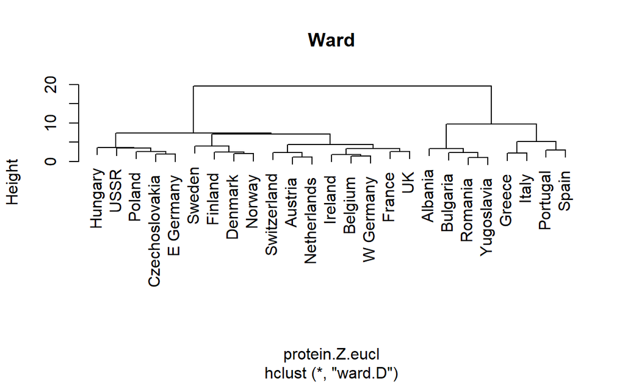

```
# 덴드로그램(나무 그림)무 그림)
plot(protein.Z.ward,                                         # 군집분석을 저장한 객체     labels = protein$country,                               # 라벨벨
     main = "Ward")
```

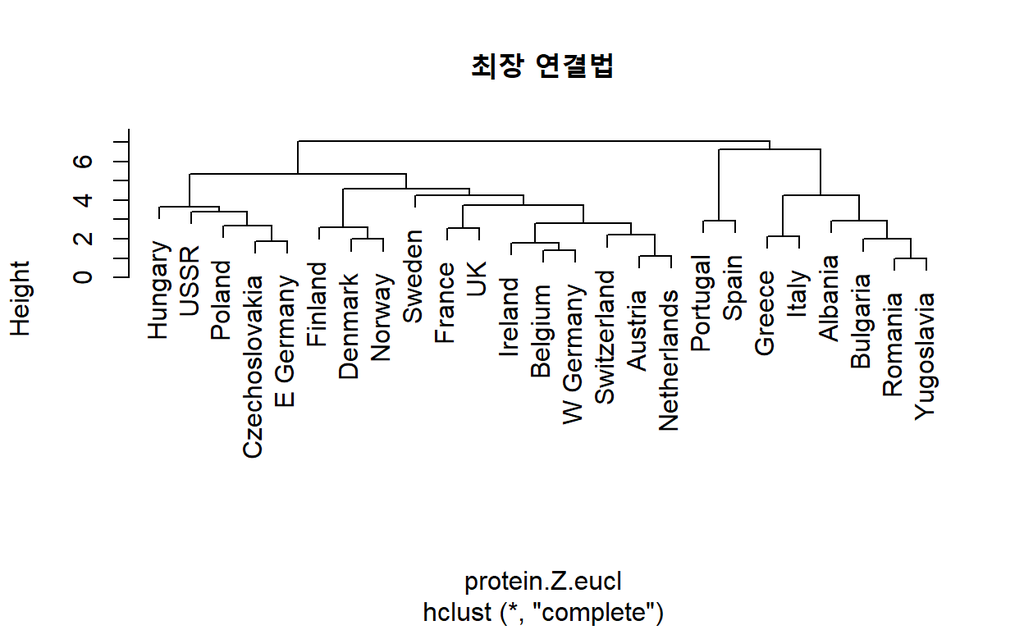

```
plot(protein.Z.comp,                                         # 군집분석을 저장한 객체     labels = protein$country,                               # 라벨벨
     main = "최장 연결법")
```

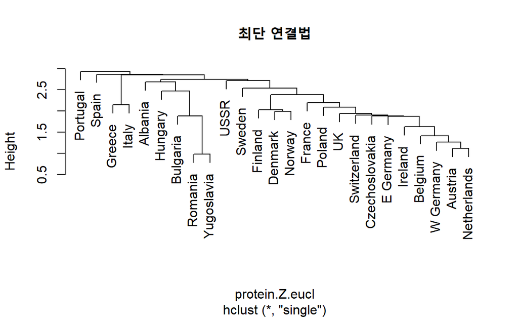

```
plot(protein.Z.sing,                                         # 군집분석을 저장한 객체     labels = protein$country,                               # 라벨벨
     main = "최단 연결법")
```

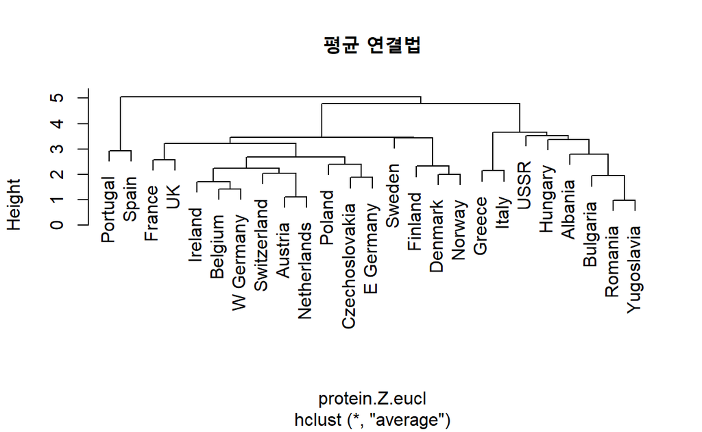

```
plot(protein.Z.aver,                                         # 군집분석을 저장한 객체     labels = protein$country,                               # 라벨벨
     main = "평균 연결법")
```

`Result!` 군집분석 방법에 따라 군집을 형성한 결과가 다르다.

`Caution!` 덴드로그램으로 계층적 군집방법을 시각화할 때, “phylo” 객체일 경우 시각화의 옵션을 다양하게 변경할 수 있다. “phylo” 객체에 대한 함수 `plot()`의 자세한 옵션은 [여기](https://www.rdocumentation.org/packages/ape/versions/5.6-2/topics/plot.phylo)를 참고한다.

```
# phylo 객체에 대한 함수 plot()
pacman::p_load("ape")                                        # For as.phylo()
```

```
  There is a binary version available but the source version
  is later:
    binary source needs_compilation
ape    5.5  5.6-2              TRUE
```

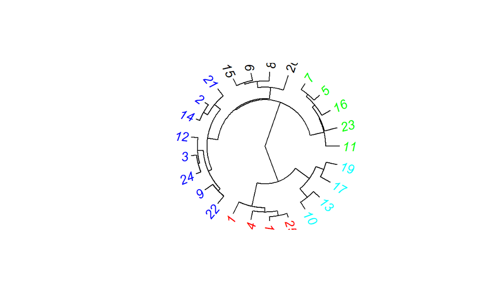

```
# 개체별 군집번호번호
hcluster <- cutree(protein.Z.ward,                           # 군집분석을 저장한 객체                   k = 5)                                    # 군집 개수수

col <- c("red", "blue", "green", "black", "cyan")

plot(as.phylo(protein.Z.ward),                               # phylo 객체
     type = "fan",                                           # 그래프 타입 ("phylogram" / "fan" / "cladogram" / "unrooted" / "radial")     tip.color = col[hcluster],                              # 라벨 색상상
     label.offset = 0.4,                                     # 라벨의 떨어짐 정도도
     cex = 1)                                                # 라벨 크기기
```

`Caution!` 함수 `rect.hclust()`를 이용하여 덴드로그램에 군집의 구분을 표현할 수 있다. 이때 옵션 `k`를 통해 분류할 군집의 개수를 지정한다.

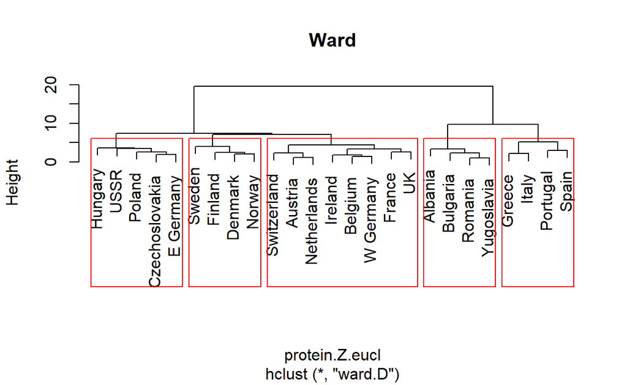

```
# 군집 구분 표현
plot(protein.Z.ward,                                         # 군집분석을 저장한 객체     labels = protein$country,                               # 라벨벨
     main = "Ward")

rect.hclust(protein.Z.ward,                                  # 군집분석을 저장한 객체            k = 5,                                           # 군집 개수수
            border = "red")                                  # 군집 구분 상자 색깔
```

## **1-5. 원자료와 군집번호 결합**

`Caution!` 함수 `cutree()`를 군집번호로 구성된 벡터를 생성하는 기능을 가지고 있으며, 이때 군집의 개수를 옵션 `k`에 지정한다.

```
# 개체별 군집번호번호
hcluster <- cutree(protein.Z.ward,                           # 군집분석을 저장한 객체                   k = 5)                                    # 군집 개수수

# 원자료와 군집번호 결합NAprotein.X.hclust <- data.frame(protein, hcluster)
protein.X.hclust
```

```
          country   x1   x2  x3   x4   x5   x6  x7  x8  x9 hcluster
1         Albania 10.1  1.4 0.5  8.9  0.2 42.3 0.6 5.5 1.7        1
2         Austria  8.9 14.0 4.3 19.9  2.1 28.0 3.6 1.3 4.3        2
3         Belgium 13.5  9.3 4.1 17.5  4.5 26.6 5.7 2.1 4.0        2
4        Bulgaria  7.8  6.0 1.6  8.3  1.2 56.7 1.1 3.7 4.2        1
5  Czechoslovakia  9.7 11.4 2.8 12.5  2.0 34.3 5.0 1.1 4.0        3
6         Denmark 10.6 10.8 3.7 25.0  9.9 21.9 4.8 0.7 2.4        4
7       E Germany  8.4 11.6 3.7 11.1  5.4 24.6 6.5 0.8 3.6        3
8         Finland  9.5  4.9 2.7 33.7  5.8 26.3 5.1 1.0 1.4        4
9          France 18.0  9.9 3.3 19.5  5.7 28.1 4.8 2.4 6.5        2
10         Greece 10.2  3.0 2.8 17.6  5.9 41.7 2.2 7.8 6.5        5
11        Hungary  5.3 12.4 2.9  9.7  0.3 40.1 4.0 5.4 4.2        3
12        Ireland 13.9 10.0 4.7 25.8  2.2 24.0 6.2 1.6 2.9        2
13          Italy  9.0  5.1 2.9 13.7  3.4 36.8 2.1 4.3 6.7        5
14    Netherlands  9.5 13.6 3.6 23.4  2.5 22.4 4.2 1.8 3.7        2
15         Norway  9.4  4.7 2.7 23.3  9.7 23.0 4.6 1.6 2.7        4
16         Poland  6.9 10.2 2.7 19.3  3.0 36.1 5.9 2.0 6.6        3
17       Portugal  6.2  3.7 1.1  4.9 14.2 27.0 5.9 4.7 7.9        5
18        Romania  6.2  6.3 1.5 11.1  1.0 49.6 3.1 5.3 2.8        1
19          Spain  7.1  3.4 3.1  8.6  7.0 29.2 5.7 5.9 7.2        5
20         Sweden  9.9  7.8 3.5  4.7  7.5 19.5 3.7 1.4 2.0        4
21    Switzerland 13.1 10.1 3.1 23.8  2.3 25.6 2.8 2.4 4.9        2
22             UK 17.4  5.7 4.7 20.6  4.3 24.3 4.7 3.4 3.3        2
23           USSR  9.3  4.6 2.1 16.6  3.0 43.6 6.4 3.4 2.9        3
24      W Germany 11.4 12.5 4.1 18.8  3.4 18.6 5.2 1.5 3.8        2
25     Yugoslavia  4.4  5.0 1.2  9.5  0.6 55.9 3.0 5.7 3.2        1
```

`Result!` “Ward” 방법을 이용했을 때 1번 군집에 속하는 개체는 “Albania”, “Bulgaria”, “Romania”, “Yugoslavia”이다.

```
# 군집별 개체 수 수
table(protein.X.hclust$hcluster)
```

```
1 2 3 4 5
4 8 5 4 4
```

`Result!` “Ward” 방법을 이용했을 때 2번 집단에 속하는 개체들이 8개로 가장 많다.

```
# 군집별 표본 평균균
aggregate(protein.Z,                                          # 분석 대상상
          by = list(hcluster),                                # 집단 변수
          FUN = mean)                                         # 집단에 적용할 함수NA
```

```
  Group.1           x1         x2          x3         x4         x5
1       1 -0.807569986 -0.8719354 -1.55330561 -0.9351841 -1.0386379
2       2  1.011180399  0.7421332  0.94084150  0.6610479 -0.2671539
3       3 -0.570049402  0.5803879 -0.08589708 -0.3368952 -0.4537795
4       4  0.006572897 -0.2290150  0.19147892  0.7308937  1.1582546
5       5 -0.508801956 -1.1088009 -0.41248496 -0.6966863  0.9819154
          x6         x7         x8          x9
1  1.7200335 -1.4234267  0.9961313 -0.64360439
2 -0.6877583  0.2288743 -0.5083895  0.02161979
3  0.3181839  0.7857609 -0.2679180  0.06873983
4 -0.8722721  0.1676780 -0.9553392 -1.11480485
5  0.1300253 -0.1842010  1.3108846  1.62924487
```

`Result!` “Ward” 방법을 이용했을 때 1번 군집은 $x_6$(곡류)와 $x_8$(견과류)의 평균이 매우 크고, 그 외의 다른 변수들의 평균은 상대적으로 작음을 알 수 있다.

## **1-6. 거리행렬을 이용하는 경우**

- 만약 거리행렬이 주어졌을 때 계층적 군집분석을 수행하는 방법은 주어진 거리행렬을 함수 `as.dist()`를 이용하여 “dist” 객체로 변환하고 함수 `hclust()`를 이용하면 된다.

```
# 거리행렬
exam71 <- c(0, 1, 7, 9, 1, 0, 3, 6, 7, 3, 0, 5, 9, 6, 5, 0)
exam71.matrix <- matrix(exam71, nrow = 4)
exam71.matrix
```

```
     [,1] [,2] [,3] [,4]
[1,]    0    1    7    9
[2,]    1    0    3    6
[3,]    7    3    0    5
[4,]    9    6    5    0
```

```
# dist 객체로 변환변환
exam71.dist <- as.dist(exam71.matrix)
exam71.dist
```

```
  1 2 3
2 1
3 7 3
4 9 6 5
```

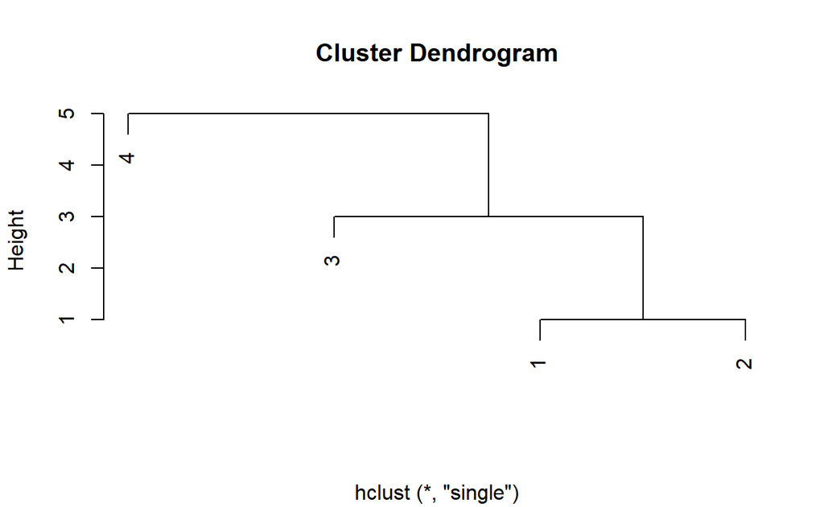

```
# 최단 연결법
exam71.sing <- hclust(exam71.dist,                           # 거리행렬
                      method = "single")                     # 최단 연결법

plot(exam71.sing, xlab = "")                                 # 덴드로그램그램
```

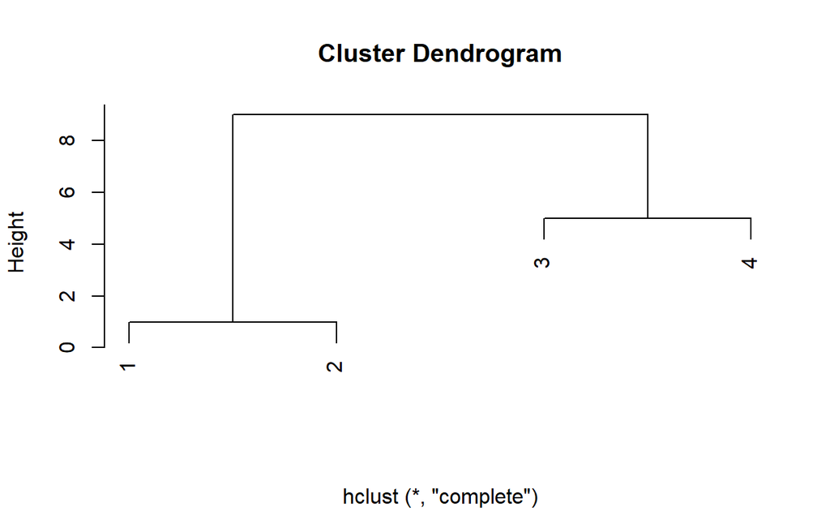

```
# 최장 연결법exam71.comp <- hclust(exam71.dist,                           # 거리행렬
                      method = "complete")                   # 최장 연결법
plot(exam71.comp, xlab = "")                                 # 덴드로그램그램
```

# **2. 비계층적 군집분석**

- 계층적 군집분석은 덴드로그램을 통해 군집이 형성되는 과정을 살펴볼 수 있으므로 분석대상이 되는 개체들의 수가 비교적 작을 때 유용하다.
- 그러나 개체 수가 커지면 이와 같은 유용성이 떨어질 뿐만 아니라, 거리행렬의 계산에 매우 많은 시간과 컴퓨터 용량이 필요하므로 적용에 제약이 따르게 된다.
- 비계층적 군집분석은 계층적인 방법으로 군집을 형성하지 않고 개체를 몇 개의 군집으로 분리시키는 방식을 택하고 있다.
- 이러한 방법은 통상적으로 미리 규정된 판정기준을 최적화시키도록 시도하고 있으며, 대부분의 경우 연구자에 의해 군집의 개수가 미리 결정되어 있어야 한다.
- 한편, 계층적인 방법에서 초기에 부적절한 병합이 발생했을 때 수정할 수 없다는 단점을 비계층적 군집분석에서는 개체의 재할당을 통해 극복할 수 있다.
- 일반적으로 비계층적 군집분석에서는 하나 이상의 수치형 변수들로부터 계산되는 유클리드 거리에 기초하여 군집이 형성된다.
- 또한, 통상 다음과 같은 단계를 거쳐 분석이 수행되는데 이러한 방법을 `k-평균 군집분석(k-means Clustering)`이라고도 한다.
  1. 군집 초기값의 선택
     - 주어진 군집의 개수 $k$만큼 군집 초기값(Cluster Seed)이 선택된다.
     - 이때 초기값을 선택하기 위해 주로 사용되는 방법들은 다음과 같다.
       - 자료에서 처음 $k$개의 개체들을 초기값으로 선택한다.
       - 자료에서 임의로 $k$개의 개체들을 골라 초기값으로 선택한다.
       - 주어진 군집의 개수보다 많은 초기값들을 각 변수의 표준편차 간격으로 고르고, 오차제곱합에 기초를 둔 판정기준이 충족될 때까지 군집의 수를 감소시킨다.
  2. 초기군집의 형성
     - 각 개체들에 대하여 군집 초기값(중심)과의 거리를 계산하고, 거리가 가장 가까운 초기값에 개체들을 할당한다.
     - 이때 각 개체가 할당될 때마다 해당 군집의 중심이 그 군집에 속하는 개체들의 평균벡터로 다시 계산된다.
  3. 개체들의 재할당
     - 각 개체들을 가장 가까운 군집중심(Cluster Center)에 재할당하고 군집의 중심(평균벡터)을 다시 계산한다.
     - 군집 중심의 변화가 일정 수준 이하가 될 때까지 이와 같은 과정이 반복되어 최종 군집이 형성된다.
- k-평균 군집분석은 함수 `kmeans()`를 통해 수행할 수 있으며, 자세한 옵션은 [여기](https://www.rdocumentation.org/packages/stats/versions/3.6.2/topics/kmeans)를 참고한다.

```
# Bivariate 데이터bivariate <- read.csv("C:/Users/User/Desktop/bivariate.csv")
bivariate
```

```
   x1  x2
1 1.0 1.0
2 1.5 2.0
3 3.0 4.0
4 5.0 7.0
5 3.5 5.0
6 4.5 5.0
7 3.5 4.5
```

```
# K 군집
bivariate.kmeans <- kmeans(bivariate,                         # 데이터행렬NA= 2)                       # 군집 개수수
bivariate.kmeans
```

```
K-means clustering with 2 clusters of sizes 2, 5

Cluster means:
    x1  x2
1 1.25 1.5
2 3.90 5.1

Clustering vector:
[1] 1 1 2 2 2 2 2

Within cluster sum of squares by cluster:
[1] 0.625 7.900
 (between_SS / total_SS =  77.0 %)

Available components:

[1] "cluster"      "centers"      "totss"        "withinss"
[5] "tot.withinss" "betweenss"    "size"         "iter"
[9] "ifault"
```

```
bivariate.kmeans$iter                                         # 반복 수수
```

```
[1] 1
```

```
bivariate.kmeans$size                                         # 형성된 각 굽집의 크기(개체 수)
```

```
[1] 2 5
```

```
bivariate.kmeans$centers                                      # 각 군집별 평균벡터터
```

```
    x1  x2
1 1.25 1.5
2 3.90 5.1
```

```
# 원자료와 군집번호 결합NAbivariate.kclust <- data.frame(bivariate,
                               bivariate.kmeans$cluster)      # 개체별 군집번호번호
bivariate.kclust
```

```
   x1  x2 bivariate.kmeans.cluster
1 1.0 1.0                        1
2 1.5 2.0                        1
3 3.0 4.0                        2
4 5.0 7.0                        2
5 3.5 5.0                        2
6 4.5 5.0                        2
7 3.5 4.5                        2
```

```
# Protein 데이터protein.Z <- scale(protein[,-1], center = TRUE, scale = TRUE)
protein.Z.kmeans <- kmeans(protein.Z,                         # 데이터행렬NA= 5,                       # 군집 개수수
                           nstart = 30)                       # 군집 초기값의 집합을 주어진 수만큼 추출하여 분석NAprotein.Z.kmeans
```

```
K-means clustering with 5 clusters of sizes 4, 4, 8, 4, 5

Cluster means:
            x1         x2          x3         x4         x5
1 -0.807569986 -0.8719354 -1.55330561 -0.9351841 -1.0386379
2 -0.508801956 -1.1088009 -0.41248496 -0.6966863  0.9819154
3  1.011180399  0.7421332  0.94084150  0.6610479 -0.2671539
4  0.006572897 -0.2290150  0.19147892  0.7308937  1.1582546
5 -0.570049402  0.5803879 -0.08589708 -0.3368952 -0.4537795
          x6         x7         x8          x9
1  1.7200335 -1.4234267  0.9961313 -0.64360439
2  0.1300253 -0.1842010  1.3108846  1.62924487
3 -0.6877583  0.2288743 -0.5083895  0.02161979
4 -0.8722721  0.1676780 -0.9553392 -1.11480485
5  0.3181839  0.7857609 -0.2679180  0.06873983

Clustering vector:
 [1] 1 3 3 1 5 4 5 4 3 2 5 3 2 3 4 5 2 1 2 4 3 3 5 3 1

Within cluster sum of squares by cluster:
[1]  8.006767 18.810330 22.039942 12.856453 16.915865
 (between_SS / total_SS =  63.6 %)

Available components:

[1] "cluster"      "centers"      "totss"        "withinss"
[5] "tot.withinss" "betweenss"    "size"         "iter"
[9] "ifault"
```

```
protein.Z.kmeans$iter                                         # 반복 수수
```

```
[1] 3
```

```
protein.Z.kmeans$size                                         # 형성된 각 굽집의 크기(개체 수)
```

```
[1] 4 4 8 4 5
```

```
protein.Z.kmeans$centers                                      # 각 군집별 평균벡터터
```

```
            x1         x2          x3         x4         x5
1 -0.807569986 -0.8719354 -1.55330561 -0.9351841 -1.0386379
2 -0.508801956 -1.1088009 -0.41248496 -0.6966863  0.9819154
3  1.011180399  0.7421332  0.94084150  0.6610479 -0.2671539
4  0.006572897 -0.2290150  0.19147892  0.7308937  1.1582546
5 -0.570049402  0.5803879 -0.08589708 -0.3368952 -0.4537795
          x6         x7         x8          x9
1  1.7200335 -1.4234267  0.9961313 -0.64360439
2  0.1300253 -0.1842010  1.3108846  1.62924487
3 -0.6877583  0.2288743 -0.5083895  0.02161979
4 -0.8722721  0.1676780 -0.9553392 -1.11480485
5  0.3181839  0.7857609 -0.2679180  0.06873983
```

```
# 원자료와 군집번호 결합NAprotein.X.kclust <- data.frame(protein,
                               protein.Z.kmeans$cluster)      # 개체별 군집번호번호
protein.X.kclust
```

```
          country   x1   x2  x3   x4   x5   x6  x7  x8  x9
1         Albania 10.1  1.4 0.5  8.9  0.2 42.3 0.6 5.5 1.7
2         Austria  8.9 14.0 4.3 19.9  2.1 28.0 3.6 1.3 4.3
3         Belgium 13.5  9.3 4.1 17.5  4.5 26.6 5.7 2.1 4.0
4        Bulgaria  7.8  6.0 1.6  8.3  1.2 56.7 1.1 3.7 4.2
5  Czechoslovakia  9.7 11.4 2.8 12.5  2.0 34.3 5.0 1.1 4.0
6         Denmark 10.6 10.8 3.7 25.0  9.9 21.9 4.8 0.7 2.4
7       E Germany  8.4 11.6 3.7 11.1  5.4 24.6 6.5 0.8 3.6
8         Finland  9.5  4.9 2.7 33.7  5.8 26.3 5.1 1.0 1.4
9          France 18.0  9.9 3.3 19.5  5.7 28.1 4.8 2.4 6.5
10         Greece 10.2  3.0 2.8 17.6  5.9 41.7 2.2 7.8 6.5
11        Hungary  5.3 12.4 2.9  9.7  0.3 40.1 4.0 5.4 4.2
12        Ireland 13.9 10.0 4.7 25.8  2.2 24.0 6.2 1.6 2.9
13          Italy  9.0  5.1 2.9 13.7  3.4 36.8 2.1 4.3 6.7
14    Netherlands  9.5 13.6 3.6 23.4  2.5 22.4 4.2 1.8 3.7
```

[output cut: 37 more lines]

`Caution!` Package `cluster`에서 제공하는 함수 `clusplot()`을 이용하여 군집화의 결과를 시각적으로 표현할 수 있다. 함수 `clusplot()`은 분석 변수들에 대한 주성분점수를 이용하여 각 개체들의 위치와 군집화 결과를 이차원 그래프로 표현하며, 주성분점수를 이용한 그래프적 표현은 군집의 개수를 탐색하는 좋은 방법 중 하나이다. 함수 `clusplot()`의 자세한 옵션은 [여기](http://math.furman.edu/~dcs/courses/math47/R/library/cluster/html/clusplot.default.html)를 참고한다.

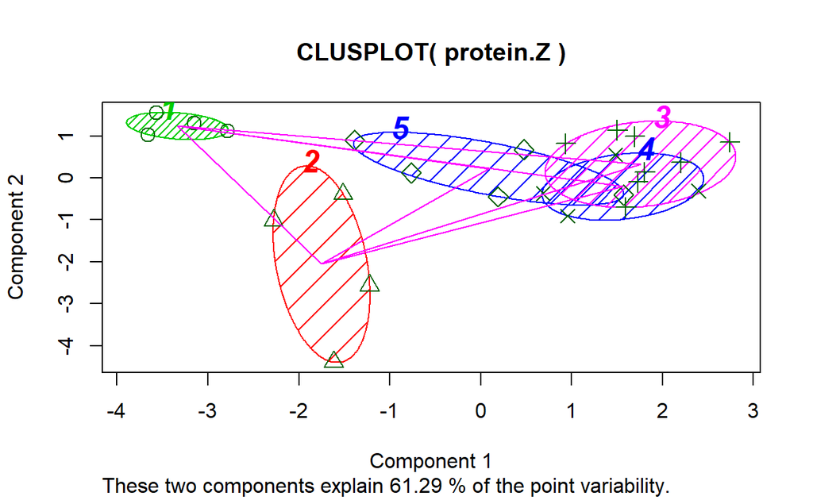

```
# 시각화화
pacman::p_load("cluster")

clusplot(protein.Z,                                           # 데이터행렬NAprotein.Z.kmeans$cluster,                            # 개체별 군집번호번호
         labels = 4,                                          # 0~5 : 군집번호 또는 개체번호를 표현할 것인지의 여부NA= 1,                                           # 0~2 : 군집들 간의 거리를 선으로 표현할 것인지의 여부         color = TRUE,                                        # 색깔을 넣을 건지의 여부         shade = TRUE,                                        # 음영을 넣을 건지의 여부
         cex = 1.5)                                           # 텍스트 크기
```

# **3. 군집의 개수**

- 군집의 개수를 결정하는 것은 쉽지 않은 문제이며, 사실 언제나 만족할 만한 결과를 제공하는 지표가 없다고 해도 과언이 아니다.
- 따라서 여러 가지 지표들을 종합적으로 판단하여 적절한 군집의 개수를 찾는 것이 바람직하다.
- 계층적 군집방법을 이용하는 경우 군집의 개수보다는 자료의 계층적 구조에 주된 관심이 있으나, 적절한 군집의 수를 결정해야 되는 경우 덴드로그램을 통해 시각적으로 이를 탐색할 수 있다.
  - 즉, 병합되는 과정에서 거리의 측도 또는 어떤 지표의 값이 상대적으로 큰 변화를 보일 경우 이를 검토할 필요가 있다.
  - 특히, Ward 방법을 이용하는 경우 군집의 개수에 따른 Error Sum of Squares (ESS)의 증분을 검토하여 급격한 변화가 일어나는 위치에서 대응되는 군집의 개수를 결정하기도 한다.
- 또한, 자료의 모분포에 대한 적절한 가정 하에서 통계적 가설검정의 틀 안에서 군집의 개수를 알아보는 방법들도 있으나, 이들도 일반적으로 만족할 만한 타당성을 제공하지는 못한다.
- 이 절에서는 군집의 개수를 결정하기 위해 널리 사용되는 몇 가지 방법과 R 함수들을 소개한다.

## **3-1. 함수 fviz_nbclust()**

- Package `factoextra`에서 제공하는 함수 `fviz_nbclust()`를 이용하면 특정 통계량에 의해 군집의 개수를 결정할 수 있다.
- 옵션 `method`를 이용하여 통계량의 이름을 지정하면 되는데, 다음과 같은 세 가지 통계량을 지정할 수 있다.
  1. `wss` (군집내 제곱합, Within-Cluster Sum of Square) : 이는 군집내 변동의 합계를 의미하며, 그 값이 작을수록 좋음을 나타낸다. 따라서, 군집의 개수가 증가함에 따라 WSS가 작아지게 되는데, `WSS가 급격히 감소하다가 감소량이 완만하게 되는 지점`이 적절한 군집의 개수에 대한 후보가 될 수 있다.
  2. `silhouette` (실루엣 계수) : 이는 각 개체들이 해당 군집에 얼마나 잘 위치하고 있는지를 측정하는 계수이며, 그 값이 클 때 군집화가 잘 되었음을 나타낸다. 일반적으로 `평균 실루엣 계수(Average Silhouette Coefficient)가` `가장 큰 지점의 군집의 개수`를 선택한다.
  3. `gap_stat` (갭 통계량) : 이는 관측된 군집간 변동과 균일분포 하에서의 군집간 변동의 기대값을 비교하는 것으로, 그 값이 클 때 군집화가 잘 되었음을 나타낸다. 일반적으로 `갭 통계량(Gap Statistic)이 가장 큰 지점`의 군집의 개수를 선택한다.
- 함수 `fviz_nbclust()`의 자세한 옵션은 [여기](https://www.rdocumentation.org/packages/factoextra/versions/1.0.7/topics/fviz_nbclust)를 참고한다.

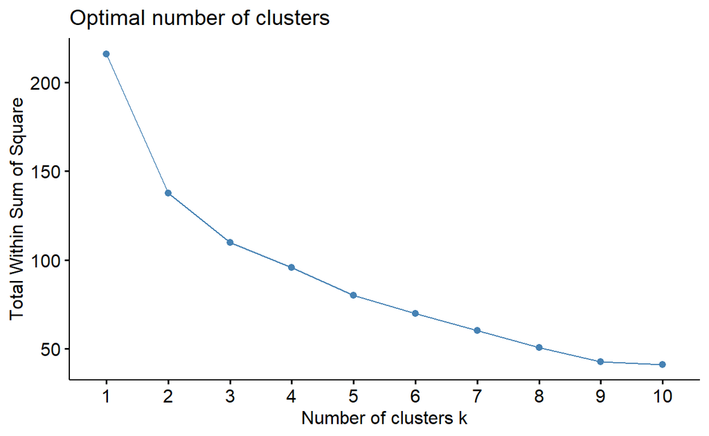

```
pacman::p_load("factoextra")

# Method = "wss"
fviz_nbclust(protein.Z,                                     # 데이터 행렬NAkmeans,                                        # 군집분석 방법법
             method = "wss",                                # 탐색할 통계량 ("wss" : 군집내 제곱합, "silhouette" : 실루엣-계수, "gap_stat" : 갭 통계량))
             k.max = 10)                                    # 탐색할 최대 군집 개수
```

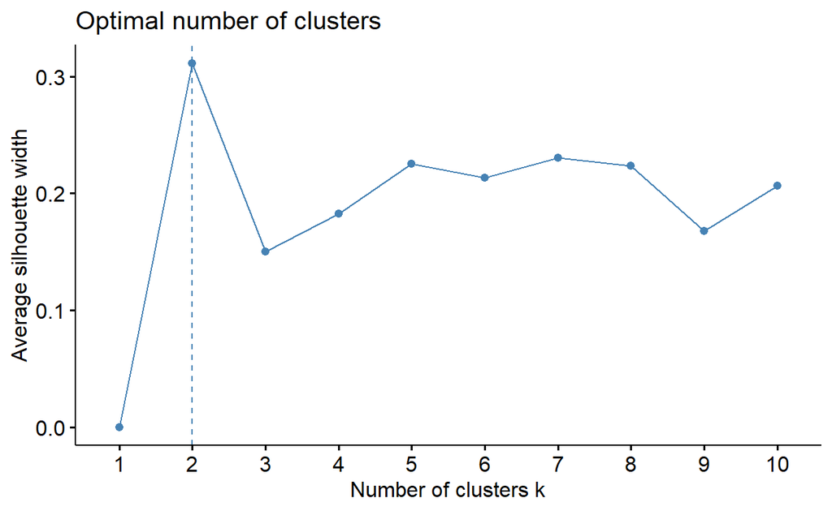

```
# Method = "silhouette"
fviz_nbclust(protein.Z,                                     # 데이터 행렬NAkmeans,                                        # 군집분석 방법법
             method = "silhouette",                         # 탐색할 통계량 ("wss" : 군집내 제곱합, "silhouette" : 실루엣-계수, "gap_stat" : 갭 통계량))
             k.max = 10)                                    # 탐색할 최대 군집 개수
```

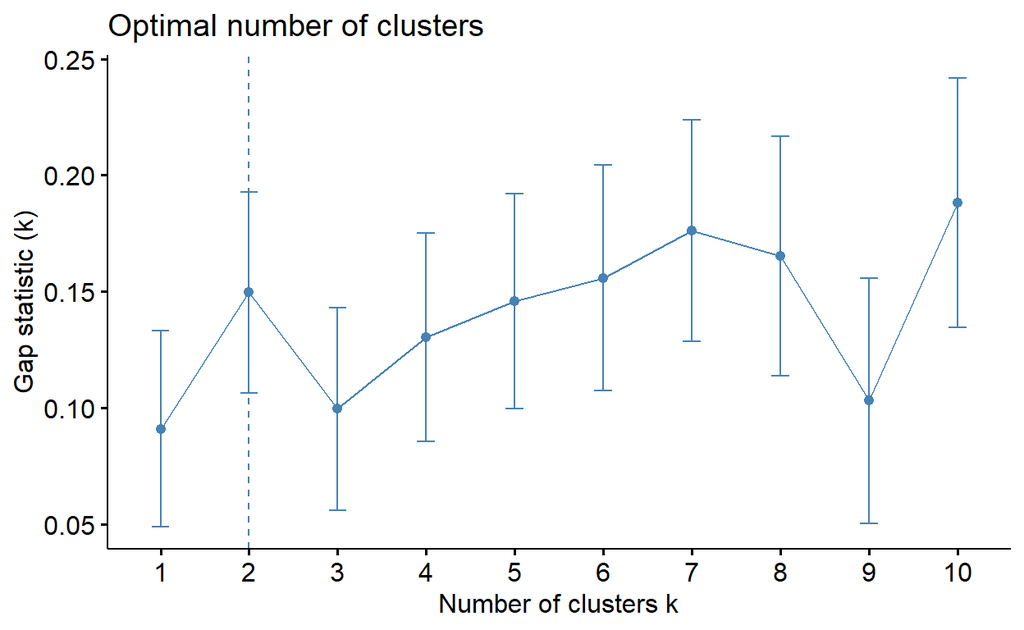

```
# Method = "gap_stat"

fviz_nbclust(protein.Z,                                     # 데이터 행렬NAkmeans,                                        # 군집분석 방법법
             method = "gap_stat",                           # 탐색할 통계량 ("wss" : 군집내 제곱합, "silhouette" : 실루엣-계수, "gap_stat" : 갭 통계량))
             nboot = 500)                                   # 붓스트랩 반복 횟수 횟수
```

## **3-2. 함수 NbClust()**

- Package `NbClust`에서 제공하는 함수 `NbClust()`는 앞에서 설명한 3가지 통계량(wss, silhouette, gap_stat)을 포함하여 30여 개의 통계량에 의해 군집의 개수를 결정할 수 있다.
- 함수 `NbClust()`의 자세한 옵션은 [여기](https://www.rdocumentation.org/packages/NbClust/versions/3.0.1/topics/NbClust)를 참고한다.

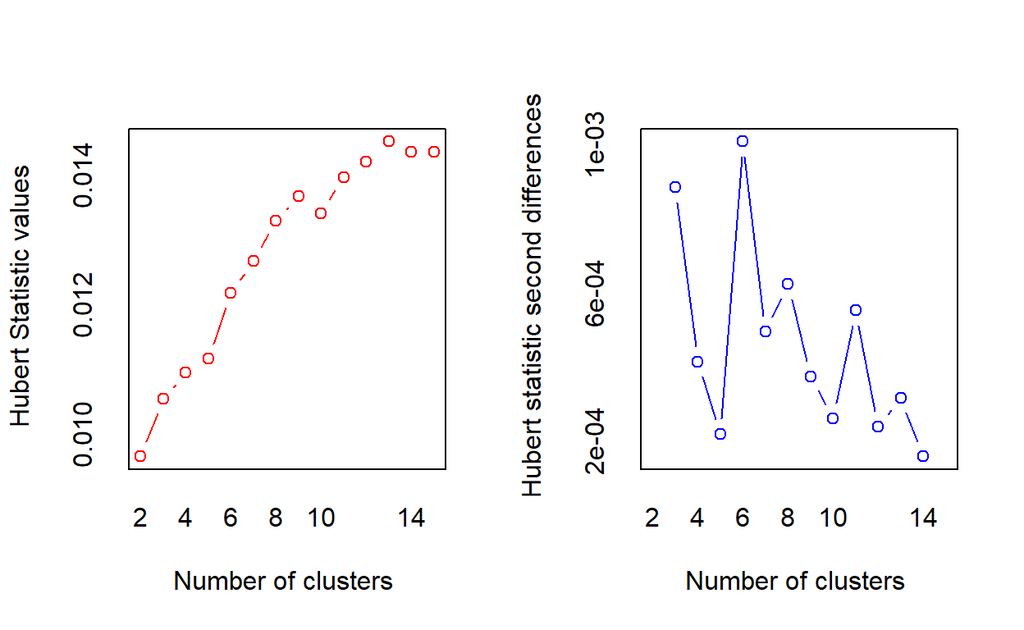

```
*** : The Hubert index is a graphical method of determining the number of clusters.
                In the plot of Hubert index, we seek a significant knee that corresponds to a
                significant increase of the value of the measure i.e the significant peak in Hubert
                index second differences plot.
```

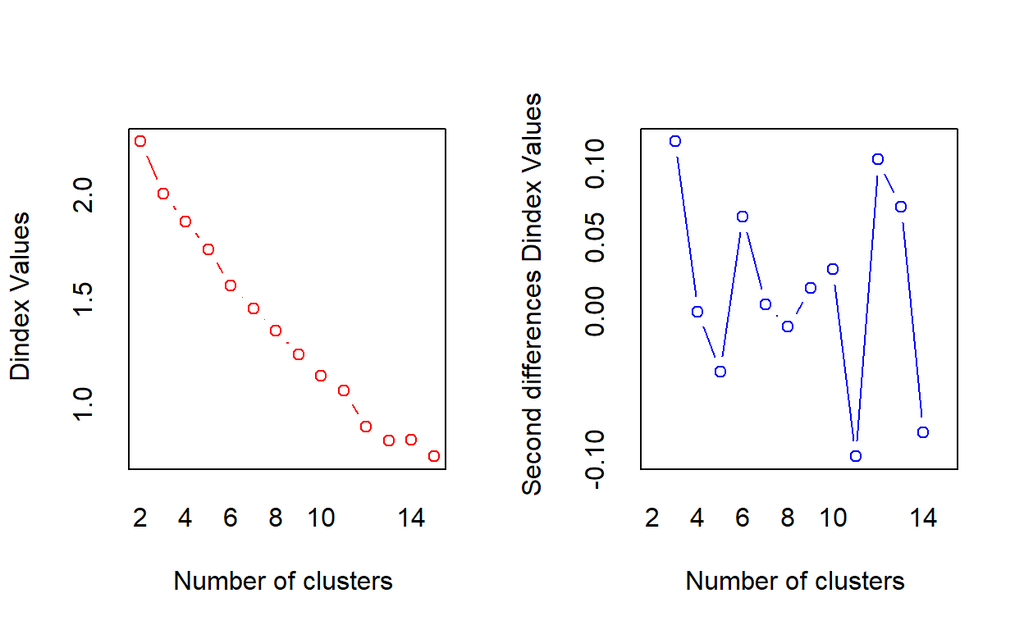

```
*** : The D index is a graphical method of determining the number of clusters.
                In the plot of D index, we seek a significant knee (the significant peak in Dindex
                second differences plot) that corresponds to a significant increase of the value of
                the measure.

* Among all indices:
* 7 proposed 2 as the best number of clusters
* 8 proposed 3 as the best number of clusters
* 1 proposed 12 as the best number of clusters
* 3 proposed 13 as the best number of clusters
* 4 proposed 15 as the best number of clusters

                   ***** Conclusion *****

* According to the majority rule, the best number of clusters is  3
```

```
pacman::p_load("NbClust")

nc <- NbClust(data = protein.Z,                             # 데이터 행렬NA= "euclidean",                       # 거리측도도
              min.nc = 2,                                   # 탐색할 최소 군집 개수              max.nc = 15,                                  # 탐색할 최대 군집 개수              method = "kmeans")                            # 군집분석 방법법
```

```
nc
```

```
$All.index
       KL      CH Hartigan     CCC    Scott      Marriot   TrCovW
2  2.7022 13.1029   5.8597 -0.0363  57.5560 5.479829e+09 371.9784
3  1.8645 10.6656   3.4545 -0.3530 113.7661 1.301607e+09 238.2300
4  1.0091  8.9522   3.1070 -0.9185 141.0133 7.780796e+08 186.4731
5  0.5691  8.0802   4.8647 -1.3944 169.4849 3.892618e+08 134.4208
6  1.5388  8.5590   3.4964 -0.8121 215.1825 9.010649e+07  88.4805
7  2.2213  8.5526   1.8289 -0.7517 240.6801 4.422940e+07  59.8435
8  0.5052  7.8737   3.2297 -1.3656 270.3849 1.760636e+07  51.6444
9  2.0289  8.0961   1.7740 -1.1075 315.1312 3.720938e+06  38.1517
10 1.1953  7.6796   1.4965 -1.6437 345.3094 1.373784e+06  32.2035
11 0.4254  7.2341   3.4134 -2.3123 395.6683 2.217576e+05  29.1912
12 1.5636  7.8837   2.4001 -1.8041 476.7473 1.030313e+04  20.1290
13 2.0728  8.0871  -0.6939 -1.8944 481.6411 9.942145e+03  11.9889
14 0.6266  6.3983   1.6477 -4.2741 462.0155 2.528026e+04  14.0784
```

[output cut: 83 more lines]

`Result!` 7개의 통계량에서 군집의 개수로 2를 추천하고 있으며, 8개의 통계량에서 군집의 개수를 3으로 추천하고 있다. “$All.index”를 통해 각 통계량에 대하여 군집의 개수에 따른 측정값을 볼 수 있으며, “$Best.nc”에서는 각 통계량에 대해 최적의 군집 개수를 출력하고 있다. “$Best.partition”에서 최적의 군집 개수에 대한 개체별 군집번호를 출력하고 있으며, 이 예제에서는 가장 많은 통계량이 최적의 군집 개수로 3을 추천하고 있기 때문에, 총 3군집으로 나누어졌다.

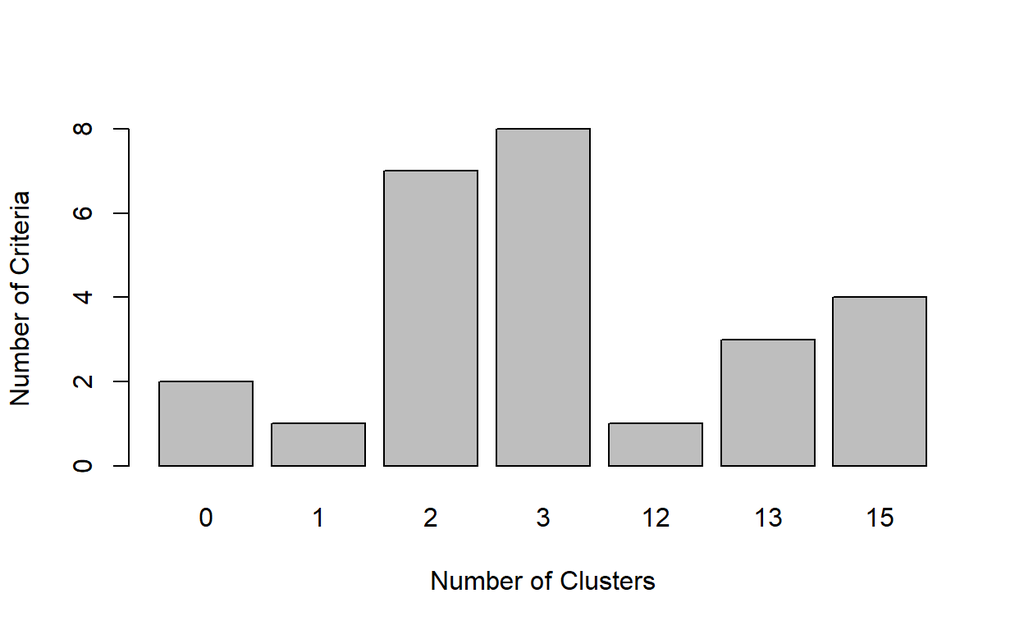

```
# 막대그래프프
barplot(table(nc$Best.n[1,]),                               # 군집 개수에 대한 도수분포표표
        xlab = "Number of Clusters",
        ylab = "Number of Criteria")
```

`Caution!` 옵션 `index`에 특정 통계량의 이름을 지정하면, 해당 통계량에 대한 결과를 자세히 볼 수 있다. 아래의 예는 가장 널리 사용되는 통계량 중 하나인 Cubic Clustering Criterion (CCC) 통계량의 결과를 보여주고 있다.

```
# 특정 통계량에 대한 최적의 군집 개수NANbClust(data = protein.Z,                                   # 데이터 행렬NA= "euclidean",                             # 거리측도도
        min.nc = 2,                                         # 탐색할 최소 군집 개수        max.nc = 15,                                        # 탐색할 최대 군집 개수        method = "kmeans",                                  # 군집분석 방법법
        index = "ccc")                                      # 탐색할 통계량
```

```
$All.index
      2       3       4       5       6       7       8       9
-0.0363 -0.3530 -0.9185 -1.3944 -0.8121 -0.7517 -1.3656 -1.1075
     10      11      12      13      14      15
-1.6437 -2.3123 -1.8041 -1.8944 -4.2741 -4.8571

$Best.nc
Number_clusters     Value_Index
         2.0000         -0.0363

$Best.partition
 [1] 1 2 2 1 2 2 2 2 2 1 1 2 1 2 2 2 1 1 1 2 2 2 1 2 1
```